# Dry bulk density - modelling

# Install packages

```r
rm(list=ls())

if(!require("pacman")) install.packages("pacman"); library(pacman)
p_load(here,
       terra,
       dplyr,
       caret,
       ggplot2,
       sf,
       CAST,
       lwgeom,
       geosphere,
       quantregForest,
       doParallel,
       ModelMetrics,
       forcats)
```

# Preparation

## Which sediment depth interval?

sf: 0 - 2 cm ss: 2 - 5 cm

```r
dpt <- "sf"
```

## Get date of latest DBD_sf and OC_sf predictions

```r
date1 <- list.files(path = here("dbd_model", "data", "final"), pattern = "DBD_sf_median_")
date1 <- sub(".*?DBD_sf_median_(.*?).tif*", "\\1", date1)
date1 <- as.Date(date1)
date1 <- max(date1)

date2 <- list.files(path = here("toc_model", "data", "final"), pattern = "OC_sf_median_")
date2 <- sub(".*?OC_sf_median_(.*?).tif*", "\\1", date2)
date2 <- as.Date(date2)
date2 <- max(date2)
```

## Load required data

```r
DBD <- vect(here("dbd_model", "data", "interim", paste0("DBD_", dpt, ".shp")))
AoI <- read_sf(here("dbd_model", "data", "interim", "AoI.shp"))

predictors <- rast(here("dbd_model", "data", "interim", "predictors.tif"))
if(dpt == "ss"){
  DBDabove <- rast(here("dbd_model", "data", "final", paste0("DBD_sf_median_", date1, ".tif")))
  predictors <- c(predictors, DBDabove)
  names(predictors)[[length(names(predictors))]] <- "DBD_sf"
  rm(DBDabove)
} else {
  OC <- rast(here("toc_model", "data", "final", paste0("OC_sf_median_", date2, ".tif")))
  predictors <- c(predictors, OC)
  names(predictors)[46] <- "OC_sf"
}

names(predictors)
```

```
 [1] "BATH"      "DIST"      "TPI25"     "TPI75"     "TPI125"    "PPmean"    "PPmax"     "CHLmean"   "CHLmax"    "SPMmean"   "SPMmax"    "pCO2min"   "pCO2mean"  "pCO2max"
[15] "pCO2range" "O2min"     "O2mean"    "O2max"     "O2range"   "SICmin"    "SICmean"   "SICmax"    "SICrange"  "UVmean"    "UVmax"     "Tmin"      "Tmean"     "Tmax"
[29] "Trange"    "Smin"      "Smean"     "Smax"      "Srange"    "sSARmin"   "sSARmean"  "sSARmax"   "sSARrange" "M"         "sM"        "mS"        "S"         "CS"
[43] "Mx"        "R"         "Mos"       "OC_sf"
```

## Create regression matrix

```r
rm_dbd <- as.data.frame(terra::extract(predictors, DBD, bind = TRUE))
rm_dbd <- rm_dbd[-1] #removes first column (ID)
rm_dbd <- na.omit(rm_dbd) #removes rows with NAs
summary(rm_dbd)
```

```
      DBD              BATH               DIST            TPI25              TPI75              TPI125             PPmean           PPmax           CHLmean
 Min.   :0.3200   Min.   :-2844.74   Min.   :  4000   Min.   :-1090.72   Min.   :-1339.97   Min.   :-1360.54   Min.   : 168.9   Min.   : 252.5   Min.   :0.2076
 1st Qu.:0.6752   1st Qu.: -603.78   1st Qu.: 53178   1st Qu.:  -95.15   1st Qu.: -115.91   1st Qu.: -105.31   1st Qu.: 306.1   1st Qu.: 788.1   1st Qu.:0.5515
 Median :0.8679   Median : -346.32   Median :103264   Median :  -13.11   Median :   16.33   Median :   46.74   Median : 371.5   Median : 908.1   Median :0.6729
 Mean   :0.9469   Mean   : -523.02   Mean   :126708   Mean   :  -20.93   Mean   :   29.96   Mean   :   81.73   Mean   : 374.8   Mean   : 950.6   Mean   :0.7372
 3rd Qu.:1.2562   3rd Qu.: -257.22   3rd Qu.:189270   3rd Qu.:   28.26   3rd Qu.:  221.55   3rd Qu.:  331.50   3rd Qu.: 410.6   3rd Qu.:1055.9   3rd Qu.:0.7775
 Max.   :1.6000   Max.   :  -41.89   Max.   :392082   Max.   :  477.92   Max.   :  844.16   Max.   : 1034.10   Max.   :1224.1   Max.   :2607.9   Max.   :4.3582
     CHLmax           SPMmean           SPMmax          pCO2min         pCO2mean        pCO2max        pCO2range          O2min           O2mean          O2max
 Min.   : 0.5633   Min.   :0.5117   Min.   : 1.114   Min.   :19.96   Min.   :27.63   Min.   :30.19   Min.   : 5.619   Min.   :239.2   Min.   :280.8   Min.   :301.1
 1st Qu.: 2.1135   1st Qu.:0.6088   1st Qu.: 1.910   1st Qu.:28.31   1st Qu.:33.44   1st Qu.:37.11   1st Qu.: 7.753   1st Qu.:259.8   1st Qu.:289.3   1st Qu.:317.7
 Median : 2.8732   Median :0.6949   Median : 2.674   Median :29.77   Median :34.40   Median :38.11   Median : 8.863   Median :270.9   Median :299.1   Median :324.6
 Mean   : 3.5120   Mean   :0.7928   Mean   : 3.552   Mean   :28.78   Mean   :34.22   Mean   :38.78   Mean   : 9.997   Mean   :276.2   Mean   :306.4   Mean   :337.4
 3rd Qu.: 4.0415   3rd Qu.:0.8276   3rd Qu.: 4.288   3rd Qu.:30.29   3rd Qu.:35.61   3rd Qu.:39.71   3rd Qu.:11.774   3rd Qu.:287.0   3rd Qu.:316.6   3rd Qu.:366.6
 Max.   :17.0903   Max.   :3.0895   Max.   :54.967   Max.   :32.79   Max.   :38.88   Max.   :51.40   Max.   :20.383   Max.   :351.1   Max.   :371.9   Max.   :397.8
    O2range          SICmin             SICmean             SICmax            SICrange            UVmean            UVmax              Tmin            Tmean
 Min.   :280.8   Min.   :0.0000000   Min.   :0.000000   Min.   :0.000000   Min.   :0.000000   Min.   :0.01998   Min.   :0.09562   Min.   :-2.062   Min.   :-0.9144
 1st Qu.:289.3   1st Qu.:0.0000000   1st Qu.:0.000000   1st Qu.:0.000000   1st Qu.:0.000000   1st Qu.:0.05341   1st Qu.:0.22634   1st Qu.:-0.850   1st Qu.: 1.5619
 Median :299.1   Median :0.0000000   Median :0.000000   Median :0.000000   Median :0.000000   Median :0.06644   Median :0.28386   Median : 1.449   Median : 3.6164
 Mean   :306.4   Mean   :0.0001398   Mean   :0.043998   Mean   :0.132683   Mean   :0.132543   Mean   :0.07392   Mean   :0.29961   Mean   : 1.778   Mean   : 3.7924
 3rd Qu.:316.6   3rd Qu.:0.0000000   3rd Qu.:0.002136   3rd Qu.:0.003672   3rd Qu.:0.003014   3rd Qu.:0.08805   3rd Qu.:0.34068   3rd Qu.: 4.237   3rd Qu.: 6.4072
 Max.   :371.9   Max.   :0.0054552   Max.   :0.614910   Max.   :0.967627   Max.   :0.967055   Max.   :0.28260   Max.   :0.87524   Max.   : 6.693   Max.   : 9.3750
      Tmax             Trange             Smin           Smean            Smax           Srange            sSARmin           sSARmean           sSARmax
 Min.   :-0.6913   Min.   : 0.1689   Min.   :32.11   Min.   :34.09   Min.   :34.66   Min.   :0.007587   Min.   :0.00000   Min.   : 0.00000   Min.   : 0.0000
 1st Qu.: 3.7592   1st Qu.: 2.7539   1st Qu.:34.81   1st Qu.:34.93   1st Qu.:35.02   1st Qu.:0.116208   1st Qu.:0.00000   1st Qu.: 0.00000   1st Qu.: 0.0000
 Median : 6.1020   Median : 3.9014   Median :34.90   Median :34.98   Median :35.09   Median :0.212336   Median :0.00000   Median : 0.00000   Median : 0.0000
 Mean   : 5.9747   Mean   : 4.1968   Mean   :34.85   Mean   :35.00   Mean   :35.12   Mean   :0.273148   Mean   :0.02899   Mean   : 0.23293   Mean   : 0.6839
 3rd Qu.: 8.2978   3rd Qu.: 5.5403   3rd Qu.:34.95   3rd Qu.:35.06   3rd Qu.:35.22   3rd Qu.:0.326559   3rd Qu.:0.00000   3rd Qu.: 0.09752   3rd Qu.: 0.5670
 Max.   :15.9739   Max.   :12.5332   Max.   :35.20   Max.   :35.31   Max.   :37.22   Max.   :3.082333   Max.   :6.50660   Max.   :10.75914   Max.   :20.5807
   sSARrange             M                sM               mS               S                 CS               Mx                 R                Mos
 Min.   : 0.0000   Min.   :0.0000   Min.   :0.0000   Min.   :0.0000   Min.   :0.00000   Min.   :0.0000   Min.   :0.000000   Min.   :0.00000   Min.   :0.0000
 1st Qu.: 0.0000   1st Qu.:0.0000   1st Qu.:0.0180   1st Qu.:0.0060   1st Qu.:0.00000   1st Qu.:0.0020   1st Qu.:0.000000   1st Qu.:0.00000   1st Qu.:0.0000
 Median : 0.0000   Median :0.0100   Median :0.1820   Median :0.0560   Median :0.00200   Median :0.0250   Median :0.000000   Median :0.00300   Median :0.0040
 Mean   : 0.6549   Mean   :0.1795   Mean   :0.3422   Mean   :0.1936   Mean   :0.03424   Mean   :0.1299   Mean   :0.006782   Mean   :0.02176   Mean   :0.0921
 3rd Qu.: 0.5670   3rd Qu.:0.1705   3rd Qu.:0.7090   3rd Qu.:0.2130   3rd Qu.:0.00600   3rd Qu.:0.0985   3rd Qu.:0.002000   3rd Qu.:0.01600   3rd Qu.:0.0310
 Max.   :20.5807   Max.   :1.0000   Max.   :1.0000   Max.   :0.9820   Max.   :1.00000   Max.   :0.9940   Max.   :0.666000   Max.   :0.41800   Max.   :0.9980
     OC_sf
 Min.   :0.1000
 1st Qu.:0.5435
 Median :0.7997
 Mean   :1.0283
 3rd Qu.:1.4225
 Max.   :2.7400
```

## Type of response?

Define which property is used as response data.

```r
resp_type <- "DBD"
resp_unit <- "g/cm3"
```

# Quantile Regression Forest model

## Distances in environmental space

Distances in environmental (feature) space are computed.

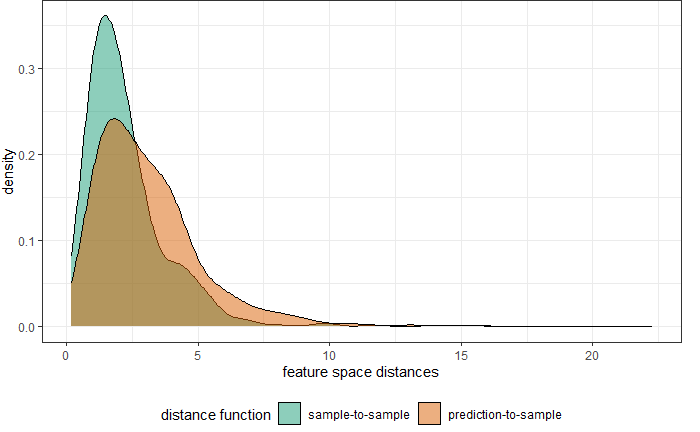

```r
dist_env <- geodist(st_as_sf(DBD),
                    predictors,
                    type = "feature"
                    )

plot(dist_env)
```

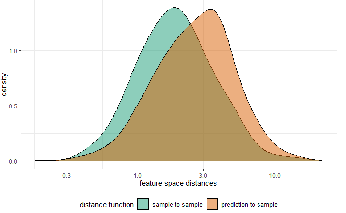

```r
plot(dist_env) + scale_x_log10()
```

## Distances in geographic space

Distances in geographic space are computed.

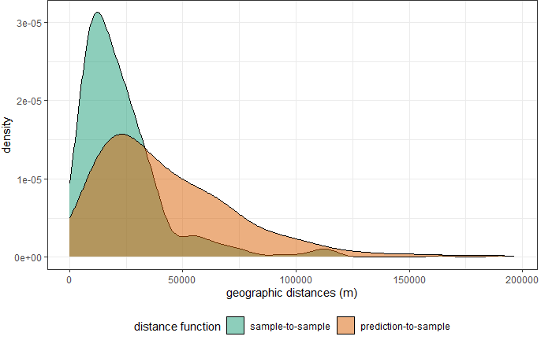

```r
dist_geogr <- geodist(st_as_sf(DBD),
                     predictors,
                     type = "geo"
                     )

plot(dist_geogr)
```

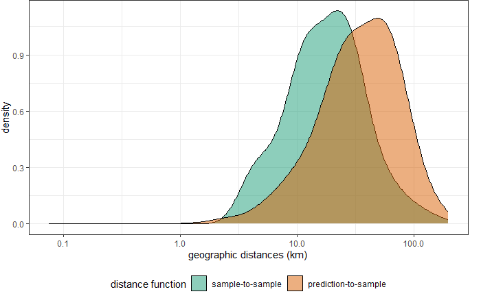

```r
plot(dist_geogr, unit="km") + scale_x_log10()
```

## Creating spatial blocks

Spatial blocks and folds are created. The folds will be used in a spatial k-fold cross validation. The k-fold nearest neighbour distance matching algorithm is used here.

```r
DBD <- project(DBD, AoI)
k <- 10 # Number of folds
knndmfolds <- knndm(tpoints = st_as_sf(DBD),
                    modeldomain = AoI,
                    k = k,
                    samplesize = 2000)
```

```
2000 prediction points are sampled from the modeldomain
```

## Distances in geographic space including CV distances

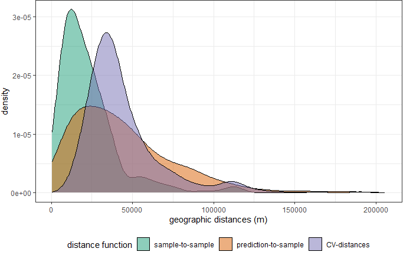

```r
dist_geogr2 <- geodist(st_as_sf(DBD),
                       predictors,
                       cvfolds= knndmfolds$indx_test,
                       type = "geo"
                       )

plot(dist_geogr2)
```

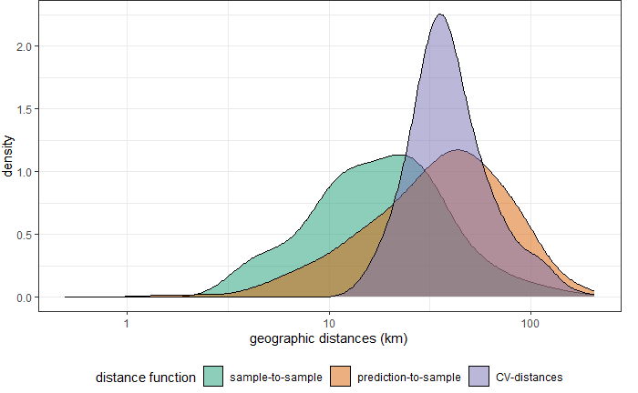

```r
plot(dist_geogr2, unit="km") + scale_x_log10()
```

## Model tuning

A Quantile Regression Forest model is tuned. Predictor variables are selected in a forward feature selection approach and various values of the mtry parameter are tested in a spatial k-fold cross validation.

The maximum number of iterations to be performed can be calculated upfront, based on the number of pre-selected predictors:

```r
factorial(length(names(predictors)))/(factorial(2)*factorial(length(names(predictors))-2)) + sum(c((length(names(predictors))-2):1))
```

```
[1] 2025
```

### Forward feature selection

The best combination of predictor variables (features) is found in a forward feature selection process.

```r
model
```

```
Selected Variables:
SICmax OC_sf PPmean Smin O2mean O2range
---
Quantile Random Forest

376 samples
  6 predictor

No pre-processing
Resampling: Cross-Validated (10 fold)
Summary of sample sizes: 336, 340, 336, 343, 340, 337, ...
Resampling results across tuning parameters:

  mtry  RMSE       Rsquared   MAE
  2     0.2023406  0.6311860  0.1410449
  4     0.1734160  0.7186581  0.1229974
  6     0.1643238  0.7534745  0.1176845

Rsquared was used to select the optimal model using the largest value.
The final value used for the model was mtry = 6.
```

### FFS plot

Plot of R2 over the model runs.

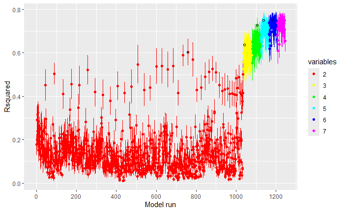

```r
plot(model)
```

## Validation statistics

The validation results of the optimal RF model.

Note that these are the statistics based on the predicted values of the selected model. These differ from the values from the tuning (above), which are the means of the k predictions based on the folds.

```r
t <- data.frame(model$pred$pred, model$pred$obs)

validation <- data.frame(mse=numeric(), rmse=numeric(), r2=numeric())
validation[1,1] <- round(sum(t$model.pred.obs - t$model.pred.pred)/nrow(t), 3)
validation[1,2] <- round(rmse(t$model.pred.obs, t$model.pred.pred), 3)
validation[1,3] <- round(cor(t$model.pred.obs, t$model.pred.pred)^2, 3)

colnames(validation) <- c("ME", "RMSE", "r2")
rownames(validation) <- NULL
validation
```

| ME | RMSE | r2 |
| --- | --- | --- |
| 0.01 | 0.166 | 0.751 |

## Validation plot

```r
p <-  ggplot(t, aes(x = model.pred.pred, y = model.pred.obs)) +
      geom_abline(intercept = 0, slope = 1, colour = "grey", linewidth = 1.2) +
      geom_smooth(method = "lm") +
      geom_point() +
      scale_fill_continuous(type = "viridis") +
      theme_bw() +
      scale_x_continuous(name = "Predicted value") +
      scale_y_continuous(name = "Observed value") +
      ggtitle(paste0(resp_type, " (", resp_unit, ")"))

p

jpeg(filename = here("dbd_model", "figures", paste0("validation_plot_",resp_type, "_",dpt , ".jpg")), width = 15, height = 10, units = "cm", res = 300)
```

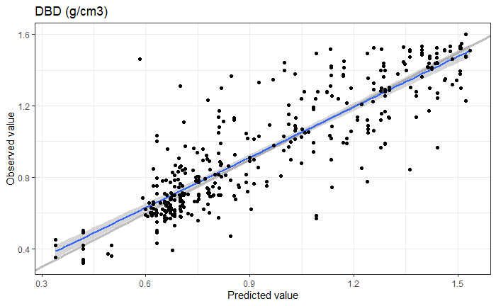

```r
p
dev.off()
```

## Variable importance

```r
imp <- varImp(model$finalModel, scale = FALSE)
imp$Predictor <- rownames(imp)
rownames(imp) <- NULL
imp <- imp[order(imp[1], decreasing = TRUE), c(2, 1)]
colnames(imp)[2] <- "IncMSE"

impfig <- imp %>%
  mutate(Predictor = fct_reorder(Predictor, IncMSE)) %>%
  ggplot( aes(x=Predictor, y=IncMSE)) +
    geom_bar(stat="identity", fill="#f68060", alpha=.6, width=.4) +
    coord_flip() +
    xlab("") +
    ylab("% increase in MSE") +
    theme_bw()

impfig

jpeg(filename = here("dbd_model", "figures", paste0("variable_importance_plot_",resp_type, "_",dpt , ".jpg")), width = 10, height = 10, units = "cm", res = 300)
```

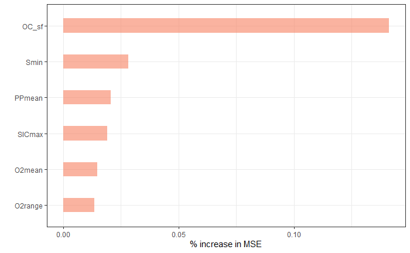

```r
impfig
dev.off()
```

## Distances in environmental space including CV distances

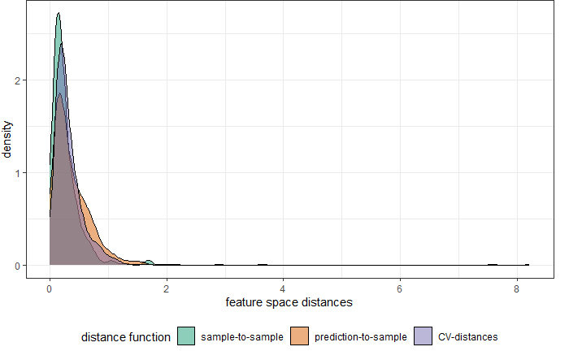

```r
dist_env2 <- geodist(st_as_sf(DBD),
                     predictors,
                     type = "feature",
                     cvfolds= knndmfolds$indx_test,
                     variables = sel_preds
                     )

plot(dist_env2)
```

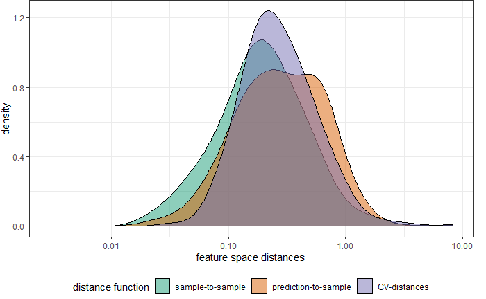

```r
plot(dist_env2) + scale_x_log10()
```

## Partial dependence

Partial dependence plots give a graphical depiction of the marginal effect of a variable on the response.

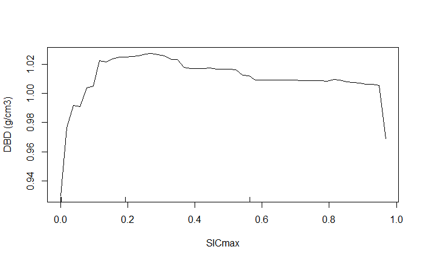

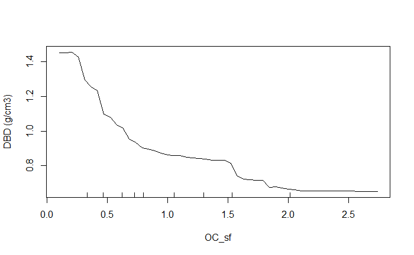

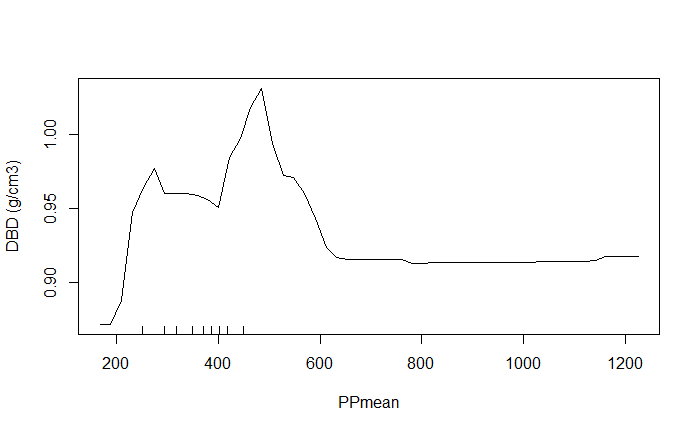

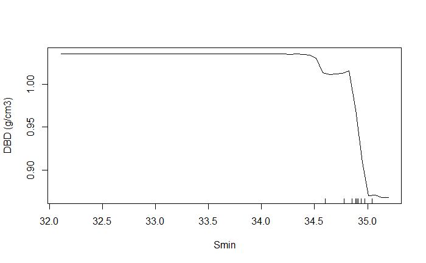

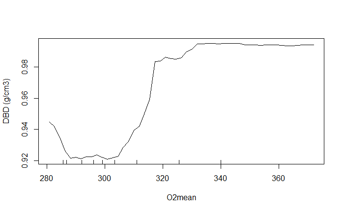

```r
m2 <- model$finalModel
class(m2) <- "randomForest"

for (i in 1:length(sel_preds)) {
  partialPlot(x = m2, pred.data = rm_dbd, x.var = sel_preds[i], main = "", xlab = sel_preds[i], ylab = paste0(resp_type, " (", resp_unit, ")"))
}
```

[figure not shown]

```r
NA
```

# Predict QRF model

## Predict DBD

DBD is predicted. Median values of the QRF distribution are calculated as central values. The 90% prediction interval and the prediction interval ratio are calculated as measures of uncertainty.

```r
preds <- raster::stack(predictors[[sel_preds]])
DBD_med <- predict(preds, model$finalModel, what = 0.5)
DBD_p95 <- predict(preds, model$finalModel, what = 0.95)
DBD_p5 <- predict(preds, model$finalModel, what = 0.05)
DBD_pi90 <- DBD_p95 - DBD_p5
DBD_pir <- DBD_pi90 / DBD_med
```

## Area of applicability

```r
DBD_trainDI <- trainDI(model = model,
                        variables = sel_preds)
```

```
Computing DI of training data...
```

```r
print(DBD_trainDI)
```

```
DI of 376 observation
Predictors: SICmax OC_sf PPmean Smin O2mean O2range

AOA Threshold: 0.1401281
```

```r
DBD_aoa <- aoa(newdata = predictors,
                model = model,
                trainDI = DBD_trainDI,
                variables = sel_preds,
)
```

```
Computing DI of new data...
Computing AOA...
Finished!
```

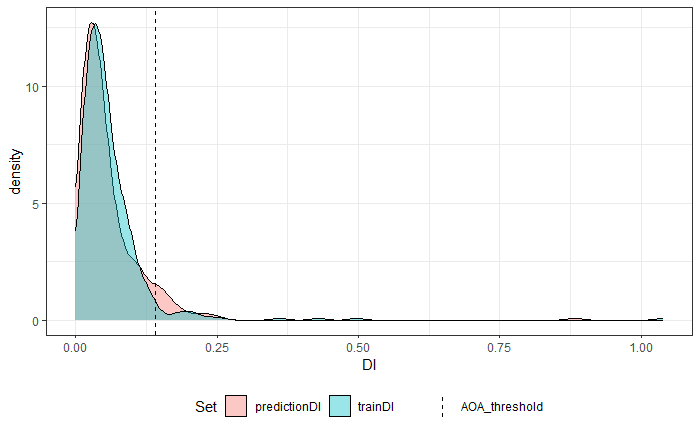

```r
plot(DBD_aoa)
```

```r
fr <- freq(DBD_aoa$AOA)
print(paste0("AOA = ", round(100*fr$count[2]/ sum(fr$count),2), "% of pixels"))
```

```
[1] "AOA = 93.44% of pixels"
```

## Plot results

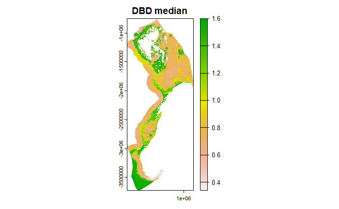

```r
plot(rast(DBD_med), main = "DBD median")
```

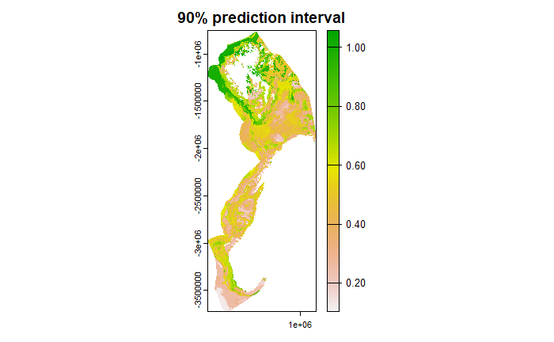

```r
plot(rast(DBD_pi90), main = "90% prediction interval")
```

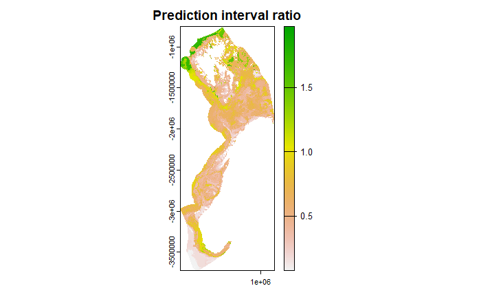

```r
plot(rast(DBD_pir), main = "Prediction interval ratio")
```

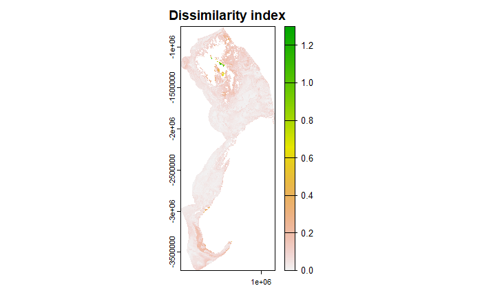

```r
plot(DBD_aoa$DI, main = "Dissimilarity index")
```

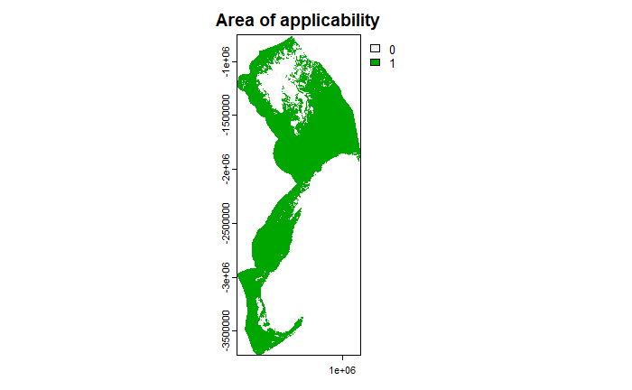

```r
plot(DBD_aoa$AOA, main = "Area of applicability")
```

## Convert AOA from raster to polygon

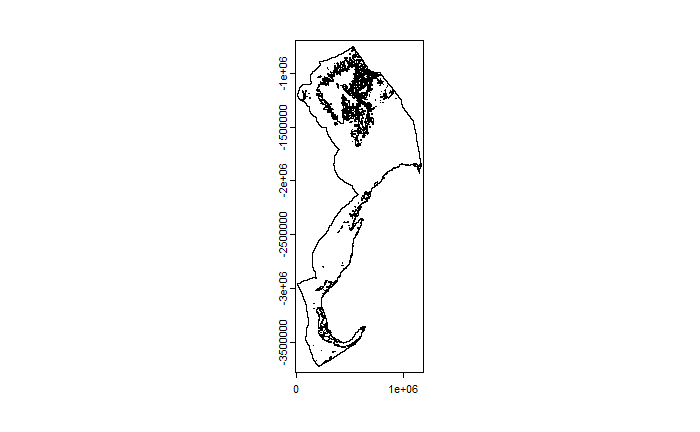

```r
aoa_poly <- as.polygons(DBD_aoa$AOA, dissolve = TRUE)
plot(aoa_poly)
```

```r
write_sf(st_as_sf(aoa_poly), dsn = here("dbd_model", "data", "final"), layer = paste0("DBD_", dpt, "_AOA_", Sys.Date()), driver = "ESRI Shapefile")
```

## Export results

```r
writeRaster(DBD_med, paste0(here("dbd_model", "data", "final"), "/DBD_", dpt, "_median_", Sys.Date(), ".tif"))
writeRaster(DBD_p5, paste0(here("dbd_model", "data", "final"), "/DBD_", dpt, "_P5_", Sys.Date(), ".tif"))
writeRaster(DBD_p95, paste0(here("dbd_model", "data", "final"), "/DBD_", dpt, "_P95_", Sys.Date(), ".tif"))
writeRaster(DBD_pi90, paste0(here("dbd_model", "data", "final"), "/DBD_", dpt, "_PI90_", Sys.Date(), ".tif"))
writeRaster(DBD_pir, paste0(here("dbd_model", "data", "final"), "/DBD_", dpt,  "_PIR_", Sys.Date(), ".tif"))
writeRaster(DBD_aoa$DI, paste0(here("dbd_model", "data", "final"), "/DBD_", dpt, "_DI_", Sys.Date(), ".tif"))
writeRaster(DBD_aoa$AOA, paste0(here("dbd_model", "data", "final"), "/DBD_", dpt, "_AOA_", Sys.Date(), ".tif"))
```

## Output a log file

```r
sink(file = paste0(here("dbd_model", "data", "final", paste0("ModelLog_DBD_", dpt, "_")), Sys.Date(), ".txt"))
model
print("Final Model")
paste0("ME = ", validation[1,1])
paste0("RMSE = ", validation[1,2])
paste0("R2 = ", validation[1,3])
paste0("AOA = ", round(100*fr$count[2]/ sum(fr$count),2), "% of pixels")
sink()
```